# Name: Yousef Al-ghanim

# ID: 2122123716

# Final Project

# Phenomenon:

## Exploratory Data analysis (EDA) in social media customer service for top 20 most active english speaking airlines.

# Tools used:

- Pandas
- Jupyter notebook
- Altair
- Sklearn
- Numpy
- NLTK
- Matplotlib
- python built in libraries (re, datetime)
- Tweepy

# Data collection:

```python
airlines_df.loc[:,['description','statuses_count','user_name','user_screen_name','user_lang']].head(20)
```

|  | description | statuses_count | user_name | user_screen_name | user_lang |
| --- | --- | --- | --- | --- | --- |
| 0 | We’re here to offer advice and inspiration for... | 1794976 | American Airlines | AmericanAir | en |
| 1 | JAL（日本航空）の「今」をお伝えする公式アカウントです！「誰かに話したくなっちゃう！」そん... | 1175864 | JAPAN AIRLINES【JAL】 | JAL_Official_jp | ja |
| 2 | Official global account of KLM. While we keep ... | 951562 | Royal Dutch Airlines | KLM | en |
| 3 | Official British Airways Twitter account. We l... | 871422 | British Airways | British_Airways | en |
| 4 | Conversations with you here are 280 characters... | 866650 | United | united | en |
| 5 | Official account of Delta Air Lines. We’re lis... | 611941 | Delta | Delta | en |
| 6 | http://t.co/O12EYOWlB1 Deals, Offers for All F... | 538295 | Qatar Flights | qatarflights | en |
| 7 | We run on #SouthwestHeart. Follow for news & s... | 534825 | Southwest Airlines | SouthwestAir | en |
| 8 | Hi, nice to tweet you! Fly with us to 101 dest... | 485314 | JetBlue Airways | JetBlue | en |
| 9 | #AvGeek researching and writing things about a... | 225071 | Jason Rabinowitz | AirlineFlyer | en |
| 10 | Official account of Alaska Airlines. Our Socia... | 189825 | Alaska Airlines | AlaskaAir | en |
| 11 | Welcome to Turkish Airlines Customer Support! ... | 177372 | TK HelpDesk | TK_HelpDesk | tr |
| 12 | NaN | 177199 | US Airways | USAirways | en |
| 13 | Travel Agent from Caracas. Find special offers... | 174762 | GregoriaTravels 2.0 | GregoriaTravels | en |
| 14 | The official Frontier Airlines customer servic... | 147673 | Frontier Airlines | FrontierCare | en |
| 15 | Worked in Sales & Marketing4Overseas National ... | 142226 | Sweet Little Sheila | Andromodid | en |
| 16 | 19,,, who is airways | 134677 | ｎａｔｉ | illegalxsong | en |
| 17 | Hotel Booking International and Domestic Airli... | 134636 | Flight Ticket Hotels | Flight_Tickets | en |
| 18 | Your go-to source for travel news. Covering ev... | 112294 | TravelPulse | TravelPulse | en |
| 19 | Hello Twitterattis! You can tweet to us with #... | 107852 | Jet Airways | jetairways | en |

```python
# filtering the verified and english accounts
top_20_airlines_df = airlines_df[(airlines_df.verified==True) & (airlines_df.user_lang == 'en')].reset_index(drop=True).head(39)
top_20_airlines_df.loc[:,['description','statuses_count','user_name','user_screen_name','user_lang']].head(20)
```

|  | description | statuses_count | user_name | user_screen_name | user_lang |
| --- | --- | --- | --- | --- | --- |
| 0 | We’re here to offer advice and inspiration for... | 1794976 | American Airlines | AmericanAir | en |
| 1 | Official global account of KLM. While we keep ... | 951562 | Royal Dutch Airlines | KLM | en |
| 2 | Official British Airways Twitter account. We l... | 871422 | British Airways | British_Airways | en |
| 3 | Conversations with you here are 280 characters... | 866650 | United | united | en |
| 4 | Official account of Delta Air Lines. We’re lis... | 611941 | Delta | Delta | en |
| 5 | We run on #SouthwestHeart. Follow for news & s... | 534825 | Southwest Airlines | SouthwestAir | en |
| 6 | Hi, nice to tweet you! Fly with us to 101 dest... | 485314 | JetBlue Airways | JetBlue | en |
| 7 | #AvGeek researching and writing things about a... | 225071 | Jason Rabinowitz | AirlineFlyer | en |
| 8 | Official account of Alaska Airlines. Our Socia... | 189825 | Alaska Airlines | AlaskaAir | en |
| 9 | Hello Twitterattis! You can tweet to us with #... | 107852 | Jet Airways | jetairways | en |
| 10 | This is the OFFICIAL twitter site of Philippin... | 94662 | Philippine Airlines | flyPAL | en |
| 11 | Welcome to the official Etihad Airways Twitter... | 72080 | Etihad Airways | EtihadAirways | en |
| 12 | حساب السعودية الرسمي حيث تجدون آخر الأخبار وال... | 69405 | SAUDIA \| السعودية | Saudi_Airlines | en |
| 13 | Defining the Future of Travel. \n\nGlobal trav... | 65015 | Skift | skift | en |
| 14 | Australia's all day, every day low fares airli... | 57912 | Jetstar Airways | JetstarAirways | en |
| 15 | Africa's Leading Airline. Th... | 54950 | Kenya Airways | KenyaAirways | en |
| 16 | Our social media team is at your service for a... | 50850 | Brussels Airlines | FlyingBrussels | en |
| 17 | Official account of #QatarAirways. Follow us f... | 48429 | Qatar Airways | qatarairways | en |
| 18 | Welcome aboard Singapore Airlines on Twitter! ... | 46490 | Singapore Airlines | SingaporeAir | en |
| 19 | This is the Official Spirit Airlines Twitter a... | 37333 | Spirit Airlines | SpiritAirlines | en |

```python
# removing non-airlines accounts and non-english accounts
top_20_airlines_df = top_20_airlines_df.drop(top_20_airlines_df.index[[7,12,13,20]]).reset_index(drop=True)
top_20_airlines_df.loc[:,['description','statuses_count','user_name','user_screen_name','user_lang']].head(20)
```

|  | description | statuses_count | user_name | user_screen_name | user_lang |
| --- | --- | --- | --- | --- | --- |
| 0 | We’re here to offer advice and inspiration for... | 1794976 | American Airlines | AmericanAir | en |
| 1 | Official global account of KLM. While we keep ... | 951562 | Royal Dutch Airlines | KLM | en |
| 2 | Official British Airways Twitter account. We l... | 871422 | British Airways | British_Airways | en |
| 3 | Conversations with you here are 280 characters... | 866650 | United | united | en |
| 4 | Official account of Delta Air Lines. We’re lis... | 611941 | Delta | Delta | en |
| 5 | We run on #SouthwestHeart. Follow for news & s... | 534825 | Southwest Airlines | SouthwestAir | en |
| 6 | Hi, nice to tweet you! Fly with us to 101 dest... | 485314 | JetBlue Airways | JetBlue | en |
| 7 | Official account of Alaska Airlines. Our Socia... | 189825 | Alaska Airlines | AlaskaAir | en |
| 8 | Hello Twitterattis! You can tweet to us with #... | 107852 | Jet Airways | jetairways | en |
| 9 | This is the OFFICIAL twitter site of Philippin... | 94662 | Philippine Airlines | flyPAL | en |
| 10 | Welcome to the official Etihad Airways Twitter... | 72080 | Etihad Airways | EtihadAirways | en |
| 11 | Australia's all day, every day low fares airli... | 57912 | Jetstar Airways | JetstarAirways | en |
| 12 | Africa's Leading Airline. Th... | 54950 | Kenya Airways | KenyaAirways | en |
| 13 | Our social media team is at your service for a... | 50850 | Brussels Airlines | FlyingBrussels | en |
| 14 | Official account of #QatarAirways. Follow us f... | 48429 | Qatar Airways | qatarairways | en |
| 15 | Welcome aboard Singapore Airlines on Twitter! ... | 46490 | Singapore Airlines | SingaporeAir | en |
| 16 | This is the Official Spirit Airlines Twitter a... | 37333 | Spirit Airlines | SpiritAirlines | en |
| 17 | Memorable journeys inspired by Malaysia's dive... | 33696 | Malaysia Airlines | MAS | en |
| 18 | SA's loved low cost airline, flying between mo... | 31716 | Mango Airlines | FlyMangoSA | en |
| 19 | Your source for Hawaiian Airlines news, tips, ... | 29096 | Hawaiian Airlines | HawaiianAir | en |

# Twitter User Gender Classification

### ref: https://www.kaggle.com/crowdflower/twitter-user-gender-classification

# Twitter US Airline Sentiment

### ref: https://www.kaggle.com/crowdflower/twitter-airline-sentiment

# Number of collected tweets:75070

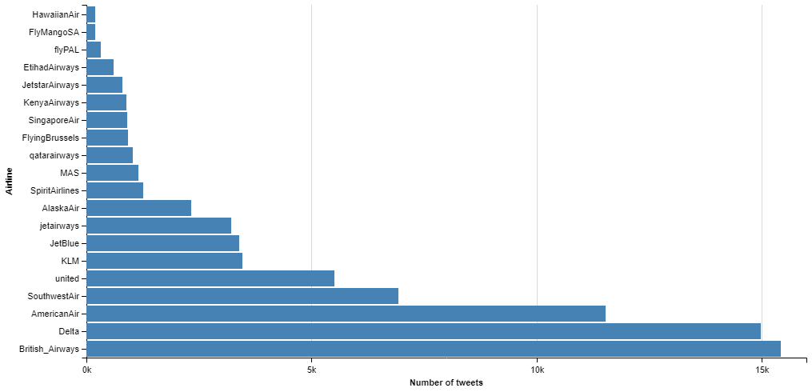

# Insights:

### 1- There is a negative relationship between text length and sentiment score.

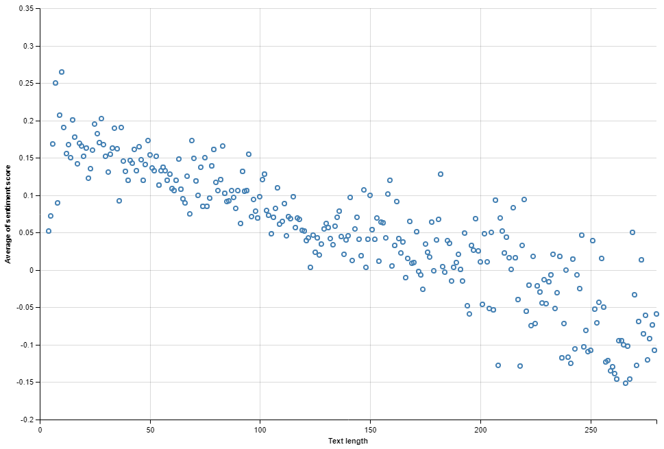

```python
from nltk.sentiment.vader import SentimentIntensityAnalyzer
sentiment_analyzer = SentimentIntensityAnalyzer()
tweets_df['sentiment_score'] = tweets_df.text.apply(lambda x: sentiment_analyzer.polarity_scores(x)['compound'])
```

### 2- Customer service is the most issue that the customer face.

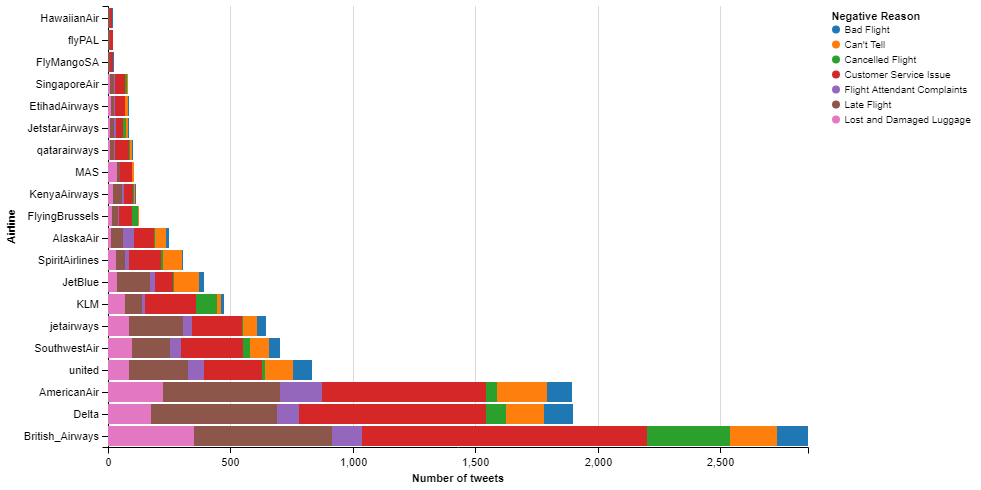

```python
from sklearn.pipeline import Pipeline
from sklearn.linear_model import SGDClassifier
from sklearn.feature_extraction.text import TfidfTransformer,CountVectorizer
from sklearn.model_selection import train_test_split,GridSearchCV,cross_val_score
from sklearn.metrics import classification_report
from nltk.stem.snowball import SnowballStemmer
from nltk.stem import WordNetLemmatizer
import re
%matplotlib inline

stemmer = SnowballStemmer("english")
lemmatizer = WordNetLemmatizer()
```

```python
reason_df = pd.read_csv('Tweets_reason.csv')
reason_df=reason_df[reason_df.airline_sentiment == 'negative'].reset_index(drop=True)
reason_df=reason_df[(reason_df.negativereason_confidence == 1) & (reason_df.airline_sentiment_confidence==1)].reset_index(drop=True)
```

```python
reason_df.negativereason.value_counts()
```

```
Customer Service Issue         1317
Late Flight                     738
Cancelled Flight                406
Lost Luggage                    387
Can't Tell                      222
Flight Attendant Complaints     120
Bad Flight                      117
Flight Booking Problems          77
Damaged Luggage                  27
longlines                        25
Name: negativereason, dtype: int64
```

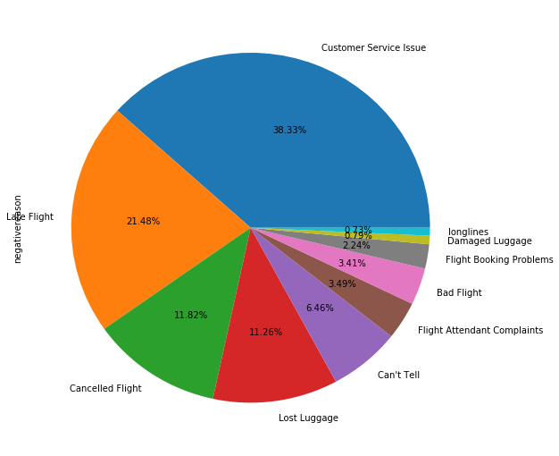

```python
reason_df.loc[(reason_df.negativereason=='Damaged Luggage') | (reason_df.negativereason=='Lost Luggage'),'negativereason']='Lost and Damaged Luggage'
reason_df=reason_df[(reason_df.negativereason!='longlines') & (reason_df.negativereason!='Flight Booking Problems')]
```

```python
reason_df.negativereason.value_counts()
```

```
Customer Service Issue         1317
Late Flight                     738
Lost and Damaged Luggage        414
Cancelled Flight                406
Can't Tell                      222
Flight Attendant Complaints     120
Bad Flight                      117
Name: negativereason, dtype: int64
```

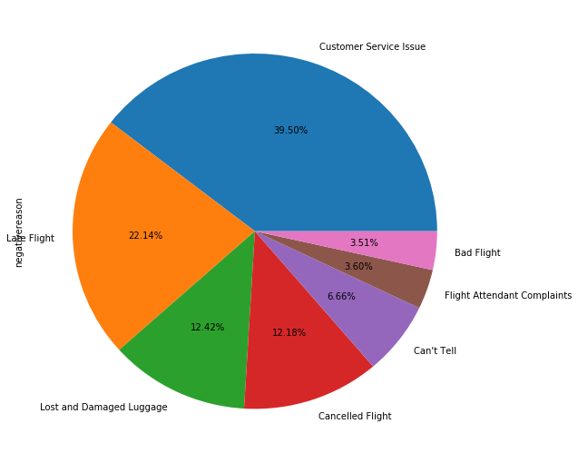

```python
text_clf = Pipeline([('vect', CountVectorizer()),
                      ('tfidf', TfidfTransformer()),
                      ('clf', SGDClassifier(loss='hinge', penalty='none',
                                            alpha=0.001,
                                       max_iter=5, tol=None,class_weight='balanced')),])
X_train, X_test, y_train, y_test = train_test_split(reason_df['text'],reason_df.negativereason,test_size=0.33,random_state=53,stratify=reason_df.negativereason)
```

```python
text_clf.fit(X_train,y_train)
predicted_test = text_clf.predict(X_test)
print(classification_report(predicted_test, y_test))
```

```
                             precision    recall  f1-score   support

                 Bad Flight       0.59      0.55      0.57        42
                 Can't Tell       0.64      0.57      0.61        82
           Cancelled Flight       0.90      0.90      0.90       133
     Customer Service Issue       0.86      0.91      0.88       413
Flight Attendant Complaints       0.54      0.51      0.53        41
                Late Flight       0.86      0.85      0.85       245
   Lost and Damaged Luggage       0.89      0.84      0.87       145

                avg / total       0.83      0.83      0.83      1101
```

```python
parameters = {
    'vect__stop_words':('english',None),
    'tfidf__norm':('l1','l2'),
    'clf__loss': ('hinge','log'),
    'clf__alpha': (0.001,0.0001,0.00001, 0.000001),
    'clf__penalty': ('l1','l2','none'),
    'clf__max_iter': [10,100,1000],
}
grid_clf = GridSearchCV(text_clf,param_grid=parameters,cv=5,n_jobs=5)
grid_clf.fit(reason_df['text'],reason_df.negativereason)
grid_clf.best_score_
```

```
0.82153569286142769
```

```python
grid_clf.best_estimator_.fit(X_train,y_train)
print(classification_report(grid_clf.best_estimator_.predict(X_test), y_test))
```

```
                             precision    recall  f1-score   support

                 Bad Flight       0.44      0.61      0.51        28
                 Can't Tell       0.73      0.69      0.71        77
           Cancelled Flight       0.92      0.88      0.90       140
     Customer Service Issue       0.88      0.90      0.89       423
Flight Attendant Complaints       0.62      0.71      0.66        34
                Late Flight       0.90      0.85      0.87       257
   Lost and Damaged Luggage       0.91      0.88      0.90       142

                avg / total       0.86      0.86      0.86      1101
```

### 3- Airlines gender distribution:

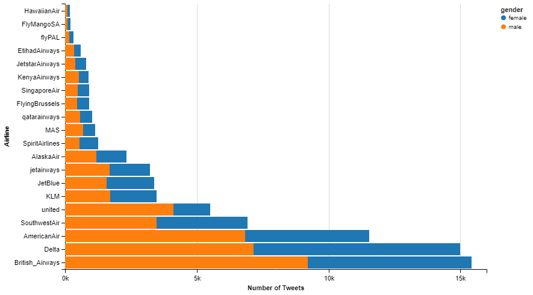

```python
gender_df = pd.read_csv('gender-classifier-DFE-791531.csv',encoding='latin1')
gender_df = gender_df[((gender_df.gender == 'male') | (gender_df.gender == "female")) & (gender_df['gender:confidence'] == 1) ].reset_index(drop=True)
```

```python
def stem_and_lem(text):
    # Remove non-ASCII chars.
    text = re.sub('[^\x00-\x7F]+',' ', text)
    # Remove double spaces.
    text = re.sub('\s+',' ',text)
    text = "".join([stemmer.stem(word) for word in text])
    text = "".join([lemmatizer.lemmatize(word) for word in text])
    return text
```

```python
gender_df.text=gender_df.text.apply(stem_and_lem)
feature_gender_df = pd.DataFrame()
feature_gender_df['features'] = ''
for k,item in enumerate(gender_df.loc[:,['text','description','sidebar_color','link_color']].astype(str).values):
    feature_gender_df.loc[k]=" ".join(item)
```

```python
gender_clf = Pipeline([('vect', CountVectorizer()),
                      ('tfidf', TfidfTransformer()),
                      ('clf', SGDClassifier(loss='hinge', penalty='l2',
                                            alpha=0.001,
                                       max_iter=5, tol=None,
                                           class_weight='balanced')),])
X_train, X_test, y_train, y_test = train_test_split(feature_gender_df.features,gender_df.gender.astype(str),test_size=0.33,random_state=0,stratify=gender_df.gender)
```

```python
parameters = {
    'vect__stop_words':('english',None),
    'tfidf__norm':('l1','l2'),
    'clf__loss': ('hinge','log','modified_huber'),
    'clf__alpha': (0.001,0.0001,0.00001, 0.000001),
    'clf__penalty': ('none','l1','l2'),
    'clf__max_iter': [10,100,1000],
}
grid_gender_clf = GridSearchCV(gender_clf,param_grid=parameters,cv=5,n_jobs=5)
grid_gender_clf.fit(feature_gender_df.features,gender_df.gender.astype(str))
grid_gender_clf.best_score_
```

```
0.70009980039920161
```

```python
grid_gender_clf.best_estimator_.fit(X_train,y_train)
print(classification_report(grid_gender_clf.best_estimator_.predict(X_test), y_test))
```

```
             precision    recall  f1-score   support

     female       0.73      0.72      0.72      1791
       male       0.67      0.68      0.68      1516

avg / total       0.70      0.70      0.70      3307
```

### Gender distribution

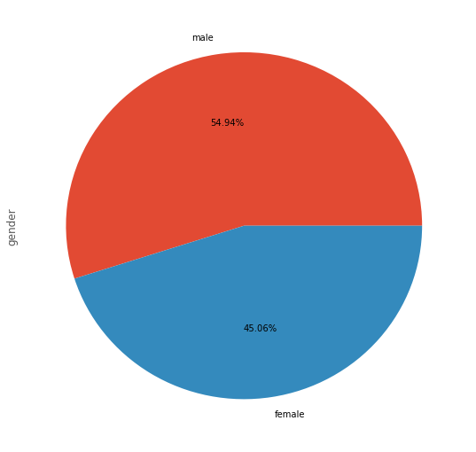

### 4- There is a positive relationship between number of followers and number of tweets.

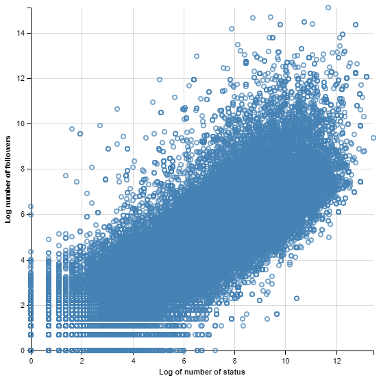

### 5- Spirit airlines has the highest negative to positive ratio out of all the other airlines

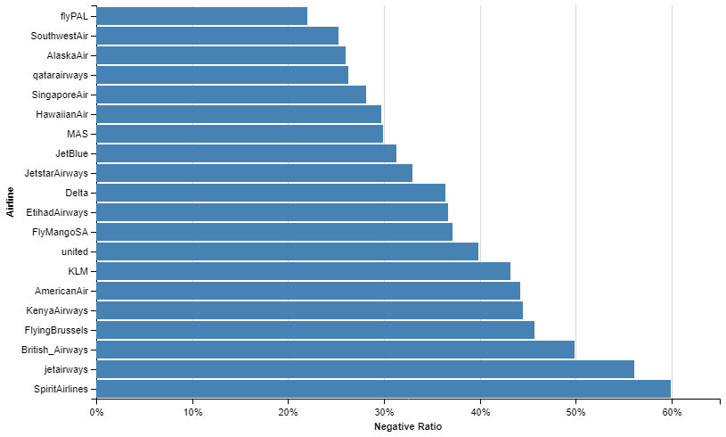

# Future directions and unanswered questions:

- What kind of respond did the cutomers got from the airlines?
- If a better accuracy has been achived in both gender and negative reason classifaction, will we find new patterns?
- Are some of the negative tweets contrived by other companies?
- Does the airlines companies treat influencers differently?

# Conclution:

- There is a negative relationship between text length and sentiment score.
- Customer service is the most issue that the customer face.
- Most of United airlines customers are males
- There is a positive relationship between number of followers and number of tweets.
- Spirit airlines has the highest negative to positive ratio out of all the other airlines